# Value-at-Risk Estimation and Backtesting

In this project, we aim to estimate the Value-at-Risk (VaR) for a portfolio consisting of two stocks, Microsoft (MSFT) and Apple (AAPL). We will use various models to calculate the VaR and backtest these models to measure their accuracy. Our goal is to identify the model that leads to the lowest capital requirement while accurately predicting risk.

## Problem Statement

We are given daily adjusted close price data for two stocks, Microsoft (MSFT) and Apple (AAPL). The portfolio consists of 50 shares of each stock. Our task is to:

1. **Calculate daily 99% VaR** for the portfolio using different models.
2. **Backtest** the calculated VaR values over the past year to measure the number of exceedances (instances where the actual loss exceeds the predicted VaR).
3. **Determine the capital requirement** for the portfolio using the formula:

$C = \max[\text{VaR}_{t-1}, m \times \text{VaR}_{\text{avg}}]$

where ( m ) is a factor based on the number of exceedances.

## VaR Models

We will use the following models to estimate VaR, grouped into three main categories:

1. **Parametric Approach**: This approach assumes that the returns follow a particular distribution, and volatility is estimated using different models:
   - **Standard Deviation (std)**: A basic measure of volatility.
   - **Exponentially Weighted Moving Average (EWMA)**: A volatility model giving more weight to recent observations.
   - **GARCH Models**:
     - GARCH with Normal distribution (no leverage effect).
     - GARCH with Generalized Error Distribution (GED) (no leverage effect).
     - GJR-GARCH with Normal distribution (with leverage effect).
     - GJR-GARCH with GED (with leverage effect).
2. **Historical Simulation**: A non-parametric approach using historical data.
3. **Monte Carlo Simulation**: A simulation-based approach for VaR estimation.

## VaR Limits and Weights

The VaR limits and weights for the exceedance calculation are defined as follows:

## Data and Portfolio

- The portfolio consists of 50 shares each of Microsoft (MSFT) and Apple (AAPL).
- The adjusted close price data for both stocks is stored in the data file.

In the following steps, we will implement and compare these models, calculate the VaR, perform backtesting, and determine the capital requirement for the portfolio.

## Parametric Approach for VaR Calculation

The Parametric Approach to VaR calculation assumes that the returns of the portfolio follow a particular statistical distribution. This approach estimates volatility using different models and then calculates VaR based on this estimated volatility.

### Volatility Models

1. **Standard Deviation (std)**: This model calculates the basic measure of volatility, assuming that past returns are indicative of future risk. It is simple and easy to implement but may not always be accurate for financial time series.
2. **Exponentially Weighted Moving Average (EWMA)**: This model gives more weight to recent observations, making it more responsive to recent changes in market conditions. It adjusts the volatility estimate dynamically.
3. **GARCH Models**:
   - **GARCH with Normal distribution (no leverage effect)**: Models volatility clustering and assumes that returns follow a normal distribution.
   - **GARCH with Generalized Error Distribution (GED) (no leverage effect)**: Similar to GARCH with a normal distribution but assumes returns follow a GED, which can better capture the fat tails in return distributions.
   - **GJR-GARCH with Normal distribution (with leverage effect)**: Extends GARCH to account for leverage effects, where volatility tends to increase more after negative shocks than positive shocks.
   - **GJR-GARCH with GED (with leverage effect)**: Combines GJR-GARCH with GED to model both leverage effects and fat tails in the return distribution.

For implementing GARCH and GJR-GARCH models, we use the `arch` package in Python. For more information, refer to the [arch documentation](https://arch.readthedocs.io/).

### VaR Calculation

Once the volatility is estimated using any of the above models, the VaR is calculated using the following formula:

$ \text{VaR}_i = \alpha \times \sigma_i \times \sqrt{h} $

where:

- $ \alpha $ is the critical value from the standard normal distribution corresponding to the confidence level (e.g., 2.33 for 99% confidence level).
- $ \sigma_i $ is the estimated volatility from model $i$ ('std', 'ewma', 'garch_normal', 'garch_ged', 'gjr_garch_normal', 'gjr_garch_ged').
- $ h $ is the time horizon (typically 1 day for daily VaR).

The VaR is then adjusted based on the initial investment:

$ \text{VaR}_{\text{adjusted}} = \text{VaR}_i \times \text{Investment}_{t-1} $

### Volatility Calculation

Volatility ($ \sigma $) for daily returns can be calculated using:

$ \sigma = \sqrt{\frac{1}{n-1} \sum_{t=1}^{n} (r_t - \bar{r})^2} $

where:

- $ n $ is the number of observations.
- $ r_t $ is the return at time $ t $.
- $ \bar{r} $ is the mean return.

By using the estimated volatility from each model, we can calculate the corresponding VaR for the portfolio.

## Historical Simulation for VaR Calculation

The Historical Simulation approach to VaR calculation does not assume any particular distribution for returns. Instead, it uses historical return data to estimate potential future losses based on past data.

### Historical Simulation

In Historical Simulation, the historical returns of the portfolio are directly used to estimate the distribution of future returns. This method is simple and intuitive, as it relies on actual historical data rather than making assumptions about the return distribution.

### VaR Calculation

The VaR is calculated by sorting the historical returns and finding the return at the desired confidence level. For example, to calculate the 99% VaR, we find the return at the 1st percentile of the sorted historical returns for each rolling window of 60 days.

$ \text{VaR}_{\text{Historical}} = \text{Percentile}(1 - \text{confidence level}) $

where:

- The confidence level is typically 99%, meaning we are interested in the 1st percentile of the returns.

The VaR is then adjusted based on the initial investment:

$ \text{VaR}_{\text{Historical, adjusted}} = \text{VaR}_{\text{Historical}} \times \text{Investment}_{t-1} $

By using the historical returns, we can calculate the corresponding VaR for the portfolio without making any distributional assumptions.

## Monte Carlo Simulation for VaR Calculation

The Monte Carlo Simulation approach to VaR calculation uses random sampling to estimate potential future losses based on the statistical properties of historical return data.

### Monte Carlo Simulation

In Monte Carlo Simulation, we generate a large number of possible future return scenarios based on the historical statistical properties of the returns. This method is flexible and can accommodate complex risk factors and distributions.

### VaR Calculation

The steps for calculating VaR using Monte Carlo Simulation are as follows:

1. **Estimate Statistical Properties**: Calculate the mean and covariance of the historical returns based on a rolling period of 60days.
2. **Generate Simulations**: Use these statistical properties to generate a large number (e.g., 1000) of possible future return scenarios.
3. **Calculate Portfolio Values**: Calculate the portfolio values for each scenario.
4. **Determine Potential Losses**: Calculate the potential losses for each scenario by comparing the simulated portfolio values to the initial investment.
5. **Calculate VaR**: Determine the VaR by finding the appropriate percentile of the distribution of potential losses.

$ \text{VaR}_{\text{Monte Carlo}} = \text{Percentile}(1 - \text{confidence level}) $

where:

- The confidence level is typically 99%, meaning we are interested in the 1st percentile of the simulated losses.

The VaR is then adjusted based on the initial investment:

$ \text{VaR}_{\text{Monte Carlo, adjusted}} = \text{VaR}_{\text{Monte Carlo}} \times \text{Investment}_{t-1} $

By using the simulated returns, we can calculate the corresponding VaR for the portfolio, incorporating a wide range of potential future scenarios.

### Monte Carlo VaR Calculation

In Monte Carlo Simulation, we generate a large number of possible future return scenarios based on the historical statistical properties of the returns. The steps for calculating VaR using Monte Carlo Simulation are as follows:

1. **Estimate Statistical Properties**: Calculate the mean and covariance of the historical returns over a rolling window.

$ \mu_t = \frac{1}{n} \sum_{i=t-n+1}^{t} r_i $

$ \Sigma_t = \frac{1}{n-1} \sum_{i=t-n+1}^{t} (r_i - \mu_t)(r_i - \mu_t)^T $

1. **Generate Simulations**: Use these statistical properties to generate a large number (e.g., 1000) of possible future return scenarios.

$ r_{t+1}^i \sim \mathcal{N}(\mu_t, \Sigma_t) $

1. **Calculate Portfolio Values**: Calculate the portfolio values for each scenario.

$ P_{t+1}^i = P_t \cdot e^{r_{t+1}^i} $

1. **Determine Potential Losses based on Values calc Above**: Calculate the potential losses for each scenario.

$ L_{t+1}^i = P_t - P_{t+1}^i $

1. **Calculate VaR**: Determine the VaR by finding the appropriate percentile of the distribution of potential losses.

$ \text{VaR}_{\text{Monte Carlo}} = \text{Percentile}(L_{t+1}^i, (1 - \text{confidence level}) \times 100\%) $

where:

- Rolling window is a window of time (e.g., 60 days) over which to calculate the mean and covariance.
- $ \mu_t $ is the mean return over the rolling window.
- $ \Sigma_t $ is the covariance matrix of returns over the rolling window.
- $ r_{t+1}^i $ are the simulated returns for the next period.
- $ P_t $ is the current portfolio value.
- $ P_{t+1}^i $ are the simulated portfolio values for the next period.
- $ L_{t+1}^i $ are the Determine Potential calc VaR based on above calc values.

The VaR is then adjusted based on the initial investment:

$ \text{VaR}_{\text{Monte Carlo, adjusted}} = \text{VaR}_{\text{Monte Carlo}} \times \text{Investment}_{t-1} $

By using the simulated returns, we can calculate the corresponding VaR for the portfolio, incorporating a wide range of potential future scenarios.

```python
# -*- coding: utf-8 -*-
"""
Created on Fri Jun 28 17:03:59 2024

@author: ritvij
"""




import pandas as pd
import numpy as np
import matplotlib.pyplot as plt
from Parameter.VaR_limit import var_limits
from Parameter.models import model
from Parameter.color_map import color_map
from Parameter.weights import weights as portfolio_weights
#
from tqdm import tqdm
from arch import arch_model
from scipy.stats import norm
import warnings
warnings.filterwarnings('ignore')
import matplotlib.colors as mcolors


class FinancialMetrics:
    def __init__(self, data):
        self.data = data
        self.returns = None

    def calculate_returns(self):
        self.returns = np.log(self.data / self.data.shift(1)).dropna()
        return self.returns

    def calculate_portfolio_volatility(self, weights, method='std',
                                    models=None,
                                    rolling_window=60, lambda_value=0.94):
        if self.returns is None:
            raise ValueError("Returns have not been calculated.")

        volatilities = []

        if method == 'std':
            for i in range(rolling_window, len(self.returns)):
                window_data = self.returns.iloc[i - rolling_window:i]
                cov_matrix = window_data.cov()
                vol = np.sqrt(np.dot(weights.T,
                                    np.dot(cov_matrix.values, weights)))
                volatilities.append(vol)

        elif method == 'ewma':
            for i in range(rolling_window, len(self.returns)):
                window_data = self.returns.iloc[i - rolling_window:i]
                weights_ewma = lambda_value ** np.arange(window_data.shape[0])[::-1]
                weights_ewma /= weights_ewma.sum()

                weighted_mean1 = np.sum(
                    window_data.iloc[:, 0] ** 2 * weights_ewma) / (
                    np.sum(weights_ewma))
                weighted_mean2 = np.sum(
                    window_data.iloc[:, 1] ** 2 * weights_ewma) / (
                    np.sum(weights_ewma))

                correlation = window_data.iloc[:, 0].corr(
                    window_data.iloc[:, 1])

                portfolio_variance = (weights[0] ** 2 * weighted_mean1 +
                                      weights[1] ** 2 * weighted_mean2 +
                                      2 * weights[0] * weights[1] *
                                      np.sqrt(weighted_mean1 * weighted_mean2)
                                      * correlation)

                volatilities.append(np.sqrt(portfolio_variance))

        elif method == 'garch':
            if models is None:
                raise ValueError("Models must be provided for GARCH method.")
            for model_spec in tqdm(models, desc='Models'):
                vol = model_spec['vol']
                dist = model_spec['dist']
                o = model_spec['o']
                print(vol, dist, f'o={o}')

                portfolio_vol = []

                for i in tqdm(range(rolling_window, len(self.returns)),
                            desc=f'{vol} {dist} o={o}', leave=False):
                    window_returns1 = self.returns[self.returns.columns[0]][
                        i-rolling_window:i]
                    window_returns2 = self.returns[self.returns.columns[1]][
                        i-rolling_window:i]

                    model1 = arch_model(window_returns1, vol=vol,
                                        p=1, o=o, q=1, dist=dist)
                    fit1 = model1.fit(disp='off')
                    cond_vol1 = fit1.conditional_volatility.iloc[-1] ** 2

                    model2 = arch_model(window_returns2, vol=vol,
                                        p=1, o=o, q=1, dist=dist)
                    fit2 = model2.fit(disp='off')
                    cond_vol2 = fit2.conditional_volatility.iloc[-1] ** 2

                    correlation = window_returns1.corr(window_returns2)

                    portfolio_variance = (weights[0] ** 2 * cond_vol1 +
                                          weights[1] ** 2 * cond_vol2 +
                                          2 * weights[0] * weights[1] * (
                                              np.sqrt(cond_vol1 * cond_vol2)
                                              * correlation))
                    portfolio_vol.append(np.sqrt(portfolio_variance))

                volatilities.append(pd.Series(portfolio_vol,
                                            index=self.returns.index[rolling_window:]))

            portfolio_volatility_garch_df = pd.DataFrame(
                {f"{model['vol']} {model['dist']} o={model['o']}":
                    vol for model, vol in zip(models, volatilities)},
                index=self.returns.index[rolling_window:]
            )

            return portfolio_volatility_garch_df

        else:
            raise ValueError(f"Method {method} not recognized.")

        dates = self.returns.index[rolling_window:]
        return pd.Series(volatilities, index=dates)

class VaRCalculator:
    def __init__(self, data, rolling_window=60, confidence_level=0.99):
        self.data = data
        self.rolling_window = rolling_window
        self.confidence_level = confidence_level
        self.weights = portfolio_weights
        self.initial_investment = (self.weights[0] * data.iloc[0, 0]) + ((
            self.weights[1] * data.iloc[0, 1]))
        self.portfolio_prices = (data * self.weights).sum(axis=1)
        self.portfolio_pnl = self.portfolio_prices.diff().dropna()

    def parametric_var(self, vol_data):
        z_score = norm.ppf(1 - self.confidence_level)
        var_results = {}

        for col in vol_data.columns:
            portfolio_std = vol_data[col]
            var = abs(
                z_score * portfolio_std * self.portfolio_prices.shift(1))
            var_results[col] = var

        return pd.DataFrame(var_results)

    def historical_var(self):
        var_series = []

        for i in range(self.rolling_window, len(self.portfolio_pnl)):
            window_data = self.portfolio_pnl.iloc[i - self.rolling_window:i]
            var = abs(
                np.percentile(
                window_data, (1 - self.confidence_level) * 100))
            var_series.append(var)
```

```python
        return pd.DataFrame(var_series,
                            index=pd.to_datetime(
                                self.portfolio_pnl.index[self.rolling_window:]),
                            columns=['Historical_VaR'])

    def Monte_Carlo_VaR(self, num_simulations=1000):
        daily_returns = self.data.pct_change().dropna()
        data = self.data
        var_series = []

        for i in range(self.rolling_window, len(daily_returns)):
            today_investment = sum(data.iloc[i] * 50)
            today_weights = data.iloc[i] * 50 / today_investment
            window_data = daily_returns.iloc[i - self.rolling_window:i]
            window_mean = window_data.mean()
            window_cov = window_data.cov()

            portfolio_mean = np.dot(today_weights, window_mean)
            portfolio_std = np.sqrt(np.dot(today_weights.T,
                                        np.dot(window_cov, today_weights)))

            simulations = np.random.normal(
                portfolio_mean,portfolio_std,(num_simulations,1))
            simulated_end_values = today_investment * np.exp(simulations)
            simulated_pnl = simulated_end_values - today_investment

            var = np.percentile(simulated_pnl, (1 - self.confidence_level) * 100)
            var_series.append(abs(var))

        return pd.DataFrame(var_series, index=pd.to_datetime(
            daily_returns.index[self.rolling_window:]),
                            columns=['Monte_Carlo_VaR'])

    def backtest_var(self, var_df):
        exceedances = (var_df.sub(self.portfolio_pnl, axis=0) < 0).astype(int)
        exceedances_df = exceedances[-252:]
        print(exceedances_df.sum())
        return exceedances_df

    def plot_exceedances(self, var_df, exceedances_df):
        portfolio_pnl = self.portfolio_pnl[-252:]
        var_df = var_df[-252:]
        for col in var_df.columns:
            plt.figure(figsize=(12, 6))
            plt.plot(var_df.index, var_df[col], label=f'VaR - {col}', color='blue')
            plt.plot(portfolio_pnl.index,
                    portfolio_pnl, label='Portfolio P&L', color='black')

            exceedance_points = portfolio_pnl[exceedances_df[col] > 0]
            plt.scatter(exceedance_points.index, exceedance_points, color='red', marker='o',
                        label='Exceedances')

            num_exceedances = exceedance_points.shape[0]
            plt.annotate(f'Number of Exceedances: {num_exceedances}',
                        xy=(0.05, 0.95),
                        xycoords='axes fraction',
                        fontsize=12, ha='left', va='top',
                        bbox=dict(boxstyle="round,pad=0.3",
                        edgecolor='black', facecolor='white'))

            plt.title(f'Portfolio P&L and VaR Exceedances for {col}')
            plt.xlabel('Date')
            plt.ylabel('Value')
            plt.legend()
            plt.show()



class VaRStatisticsCalculator:
    def __init__(self, data_path, model, rolling_window=60,
                confidence_level=0.99):

        self.data = pd.read_excel(data_path,
                                sheet_name='Data', index_col='Date')
        self.rolling_window = rolling_window
        self.confidence_level = confidence_level
        self.weights = np.array([50 * self.data.iloc[0]['AAPL'],
                                 50 * self.data.iloc[0]['MSFT']])
        self.investment = sum(self.weights)
        self.weights /= self.weights.sum()
        self.metrics = FinancialMetrics(self.data)
        self.returns = self.metrics.calculate_returns()
        self.model = model
        self.var_calculator = VaRCalculator(self.data, rolling_window,
                                            confidence_level)
        self.var_limit = var_limits
        self.color_map = color_map

    def check_data(self):
        head, tail = self.data.head(), self.data.tail()
        return head, tail


    def calculate_var(self):
        portfolio_volatility_std = (
            self.metrics.calculate_portfolio_volatility(self.weights,
                                                        method='std'))
        portfolio_volatility_ewma = (
            self.metrics.calculate_portfolio_volatility(self.weights,
                                                        method='ewma',
                                                        lambda_value=0.94))
        # portfolio_volatility_garch = (
        #     self.metrics.calculate_portfolio_volatility(self.weights,
        #                                                 method='garch',
        #                                                 models=self.model))
        # portfolio_volatility_garch.to_csv('garch.csv')

        portfolio_volatility_garch = pd.read_csv('garch.csv', index_col='Date')
        portfolio_volatility_garch.index = pd.to_datetime(portfolio_volatility_garch.index)
        historical_var_series = self.var_calculator.historical_var()
        vols = pd.concat([portfolio_volatility_std,
                        portfolio_volatility_ewma,
                        portfolio_volatility_garch], axis=1)
        vols.columns = ['std', 'ewma', 'garch_normal',
                        'garch_ged', 'gjr_garch_normal', 'gjr_garch_ged']
        var_df = self.var_calculator.parametric_var(vols)
        Monte_Carlo_VaR_value = self.var_calculator.Monte_Carlo_VaR(
            num_simulations=1000)
        Monte_Carlo_VaR_value.name = 'monte_carlo'
        all_model_VaR = pd.concat([var_df, historical_var_series,
                                Monte_Carlo_VaR_value],
                                axis=1)
        all_model_VaR.dropna(inplace=True)
        return all_model_VaR

    def calculate_and_plot_exceedances(self, all_model_VaR):
        exceedances_df = self.var_calculator.backtest_var(all_model_VaR)
        self.var_calculator.plot_exceedances(all_model_VaR, exceedances_df)
        self.exceedances_sum = exceedances_df.sum()
        self.last_row_var = all_model_VaR.iloc[-1, :]
        self.mean_last_60_days_var = all_model_VaR.iloc[-60:].mean()
        return self.exceedances_sum,self.last_row_var,self.mean_last_60_days_var
```

```python
    def plot_exceedances_with_limits(self):
        def get_color_and_limit(exceedances, var_limit):
            if exceedances < 5:
                return self.color_map['green'],var_limit['green_less_5']
            elif exceedances == 5:
                return self.color_map['amber'], var_limit['amber_5']
            elif exceedances == 6:
                return self.color_map['amber'], var_limit['amber_6']
            elif exceedances == 7:
                return self.color_map['amber'], var_limit['amber_7']
            elif exceedances == 8:
                return self.color_map['amber'], var_limit['amber_8']
            elif exceedances == 9:
                return self.color_map['amber'], var_limit['amber_9']
            else:
                return self.color_map['red'], var_limit['red_10_or_more']

        colors = []
        limit_values = []
        for col in self.exceedances_sum.index:
            exceedances = self.exceedances_sum[col]
            color, limit_value = get_color_and_limit(exceedances, self.var_limit)
            colors.append(color)
            limit_values.append(limit_value)

        plt.figure(figsize=(12, 6))
        self.exceedances_sum.plot(kind='bar', color=colors)
        for i, (exceedances, limit_value) in enumerate(
            zip(self.exceedances_sum,limit_values)):
            plt.text(i, exceedances,
                    f'{limit_value}', ha='center', va='bottom')
        plt.title('VaR Exceedances for Different Models')
        plt.xlabel('VaR Model')
        plt.ylabel('Number of Exceedances')
        plt.ylim(0, max(self.exceedances_sum) + 1)
        plt.show()
        self.m = self.exceedances_sum.apply(
            lambda x: get_color_and_limit(x, self.var_limit)[1])
        return self.m

    def calculate_capital_required(self):
        if not hasattr(self, 'm'):
            raise ValueError(
                "The 'm' values have not been calculated. Run 'plot_exceedances_with_limits' first.")
        capital_required = {}
        for col in self.last_row_var.index:
            VaR_t_minus_1 = self.last_row_var[col]
            VaR_avg = self.mean_last_60_days_var[col]
            capital_required[col] = max(
                VaR_t_minus_1, self.m[col] * VaR_avg)

        capital_required_df = pd.DataFrame.from_dict(capital_required,
                                                    orient='index',
                                                    columns=['Capital_Required'])

        # Normalize the data to map the colors
        norm = mcolors.Normalize(vmin=capital_required_df['Capital_Required'].min(),
                                vmax=capital_required_df['Capital_Required'].max())
        cmap = plt.get_cmap('RdYlGn_r')
        colors = [cmap(norm(value)) for value in capital_required_df['Capital_Required']]
        print("Capital required:")
        print(capital_required_df)

        # Plot the capital required
        fig, ax = plt.subplots(figsize=(12, 6))
        bars = ax.bar(capital_required_df.index, capital_required_df['Capital_Required'],
                    color=colors)

        # Annotate the bars
        for bar, value in zip(bars, capital_required_df['Capital_Required']):
            height = bar.get_height()
            ax.annotate(f'{value:.2f}',
                        xy=(bar.get_x() + bar.get_width() / 2, height),
                        xytext=(0, 3), textcoords="offset points",
                        ha='center', va='bottom')

        plt.title('Capital Required for Different VaR Models')
        plt.xlabel('VaR Model')
        plt.ylabel('Capital Required')
        plt.xticks(rotation=45)
        plt.grid(True)
        plt.show()

        return capital_required_df



# if __name__ == '__main__':
    # print(f'Calc of m used for calc of VaR {var_limits}')
    # print(f'Garch model used with parameters {model}')
    # print(f'portfolio weights {portfolio_weights}')


    # print(f'color map coding for matplotlib {color_map}')

#     data_path = r'D:\VaR Contest\VaR_Capital_Charge.xlsx'
#     var_statistics_calculator = VaRStatisticsCalculator(data_path, model)
#     all_model_VaR = var_statistics_calculator.calculate_var()
#     exceedances_sum, last_row_var, mean_last_60_days_var = var_statistics_calculator.calculate_and_plot_exceedances(all_model_VaR)
#     exceedances_sum.index
#     print("Sum of exceedances:")
#     print(exceedances_sum)

#     print("\nVaR values for the last available date:")
#     print(last_row_var)

#     print("\nMean VaR values over the last 60 days:")
#     print(mean_last_60_days_var)

#     m_values = var_statistics_calculator.plot_exceedances_with_limits()
#     capital_required = var_statistics_calculator.calculate_capital_required()
#     print("Capital required:")
#     print(capital_required)
```

# Class and Method Descriptions

### FinancialMetrics Class

A class to calculate financial metrics such as returns and portfolio volatility.

- **`__init__`**: Initializes the class with financial data.
- **`calculate_returns`**: Calculates logarithmic returns of the data.
- **`calculate_portfolio_volatility`**: Calculates portfolio volatility using different methods such as standard deviation, EWMA, and GARCH models.

### VaRCalculator Class

A class to calculate Value-at-Risk (VaR) using different methods and perform backtesting.

- **`__init__`**: Initializes the class with financial data, rolling window, and confidence level.
- **`parametric_var`**: Calculates parametric VaR using different volatility models.
- **`historical_var`**: Calculates historical VaR using historical returns data.
- **`Monte_Carlo_VaR`**: Calculates VaR using Monte Carlo simulation.
- **`backtest_var`**: Performs backtesting of VaR models to count exceedances.
- **`plot_exceedances`**: Plots VaR exceedances against actual portfolio P&L.

### VaRStatisticsCalculator Class

A class to calculate and analyze VaR statistics for a portfolio.

- **`__init__`**: Initializes the class with data path, models, rolling window, and confidence level.
- **`calculate_var`**: Calculates VaR using different models and combines them into a single DataFrame.
- **`calculate_and_plot_exceedances`**: Calculates and plots exceedances of VaR models.
- **`plot_exceedances_with_limits`**: Plots exceedances with corresponding color limits.
- **`calculate_capital_required`**: Calculates the capital required based on VaR models and exceedances.

### Parameter Tables

#### Calc of m used for calc of VaR

| Condition | m |
| --- | --- |
| green_less_5 | 1.5 |
| amber_5 | 1.7 |
| amber_6 | 1.76 |
| amber_7 | 1.83 |
| amber_8 | 1.88 |
| amber_9 | 1.92 |
| red_10_or_more | 2.0 |

#### Garch model used with parameters

| vol | dist | o |
| --- | --- | --- |
| Garch | normal | 0 |
| Garch | ged | 0 |
| Garch | normal | 1 |
| Garch | ged | 1 |

#### Portfolio Holdings

| Stock | Quantity |
| --- | --- |
| AAPL | 50 |
| MSFT | 50 |

#### Color map coding for matplotlib

| Color | Hex Code |
| --- | --- |
| green | #00FF00 |
| amber | #FFBF00 |
| red | #FF0000 |

```python
#file location
data_path = r'D:\VaR Contest\VaR_Capital_Charge.xlsx'
var_statistics_calculator = VaRStatisticsCalculator(data_path, model)
head,tail=var_statistics_calculator.check_data()
```

```python
print('head of the dataframe')
head
```

```
head of the dataframe
```

| Date | AAPL | MSFT |
| --- | --- | --- |
| 2021-06-25 | 133.110001 | 265.019989 |
| 2021-06-28 | 134.779999 | 268.720001 |
| 2021-06-29 | 136.330002 | 271.399994 |
| 2021-06-30 | 136.960007 | 270.899994 |
| 2021-07-01 | 137.270004 | 271.600006 |

```python
print('head of the dataframe')
tail
```

```
head of the dataframe
```

| Date | AAPL | MSFT |
| --- | --- | --- |
| 2024-06-17 | 216.669998 | 448.369995 |
| 2024-06-18 | 214.289993 | 446.339996 |
| 2024-06-20 | 209.679993 | 445.700012 |
| 2024-06-21 | 207.490005 | 449.779999 |
| 2024-06-24 | 208.139999 | 447.670013 |

```python
all_model_VaR = var_statistics_calculator.calculate_var()
```

```python
all_model_VaR.tail()
```

| Date | std | ewma | garch_normal | garch_ged | gjr_garch_normal | gjr_garch_ged | Historical_VaR | Monte_Carlo_VaR |
| --- | --- | --- | --- | --- | --- | --- | --- | --- |
| 2024-06-17 | 868.523343 | 911.638445 | 860.899297 | 896.738580 | 702.952757 | 800.953847 | 728.095225 | 781.498970 |
| 2024-06-18 | 887.586502 | 949.201366 | 814.225293 | 890.108760 | 837.528645 | 810.551226 | 728.095225 | 817.671545 |
| 2024-06-20 | 885.683717 | 921.661059 | 894.059607 | 868.980860 | 822.523937 | 820.191608 | 728.095225 | 808.993609 |
| 2024-06-21 | 873.668311 | 897.781888 | 846.498846 | 837.477981 | 821.958816 | 826.301756 | 728.095225 | 789.075421 |
| 2024-06-24 | 874.233973 | 881.853603 | 1071.944420 | 1051.861382 | 910.353301 | 1060.379452 | 728.095225 | 749.653943 |

```
std                 2
ewma                2
garch_normal        3
garch_ged           3
gjr_garch_normal    3
gjr_garch_ged       3
Historical_VaR      4
Monte_Carlo_VaR     2
dtype: int64
```

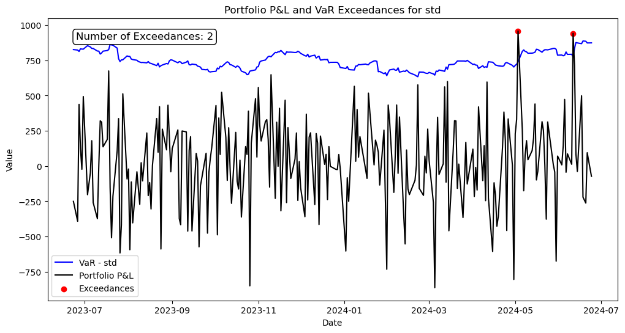

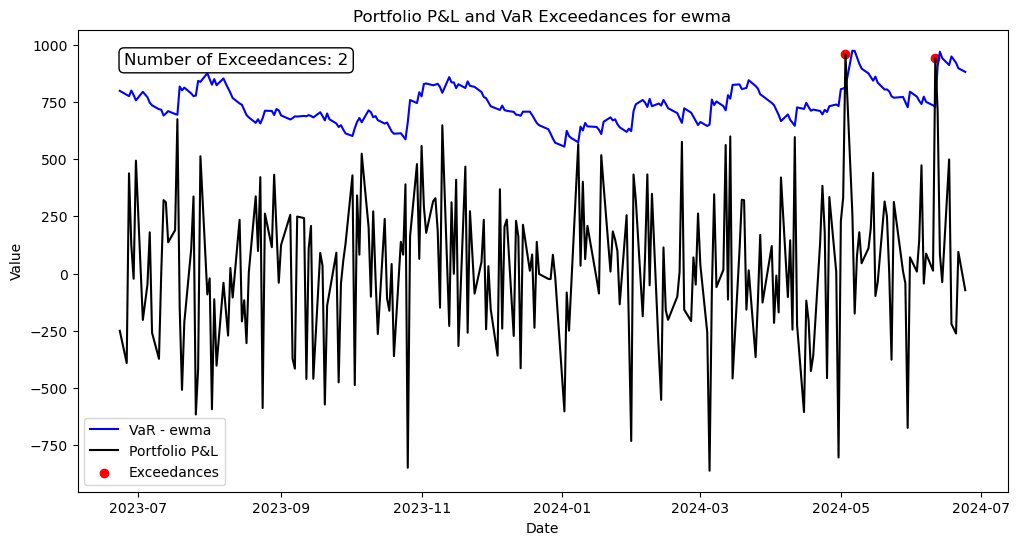

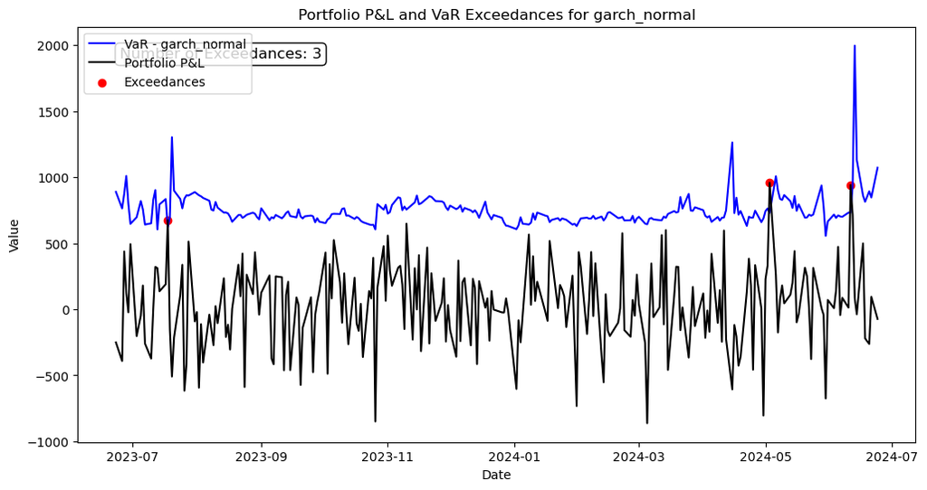

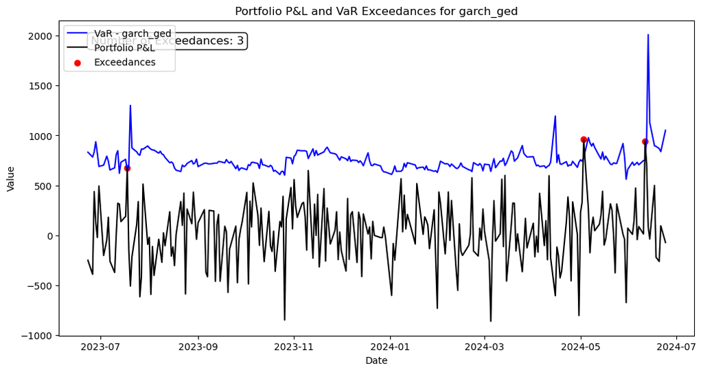

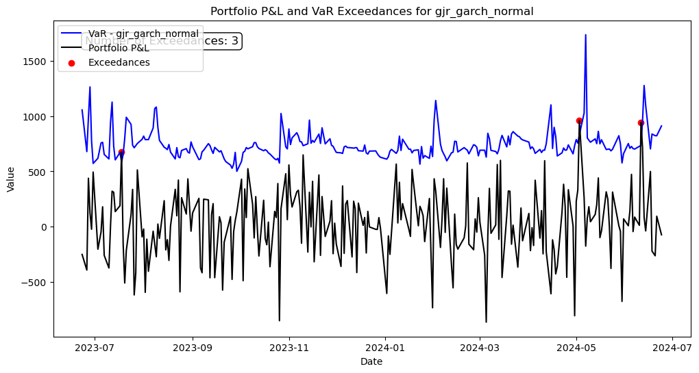

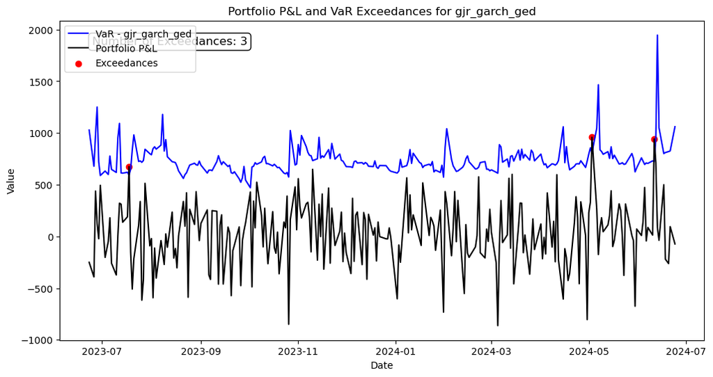

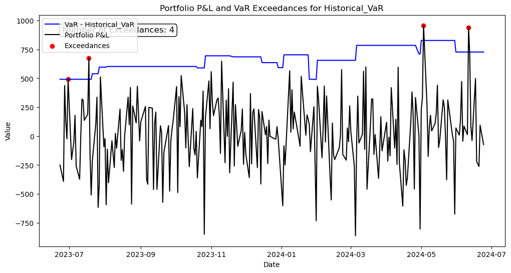

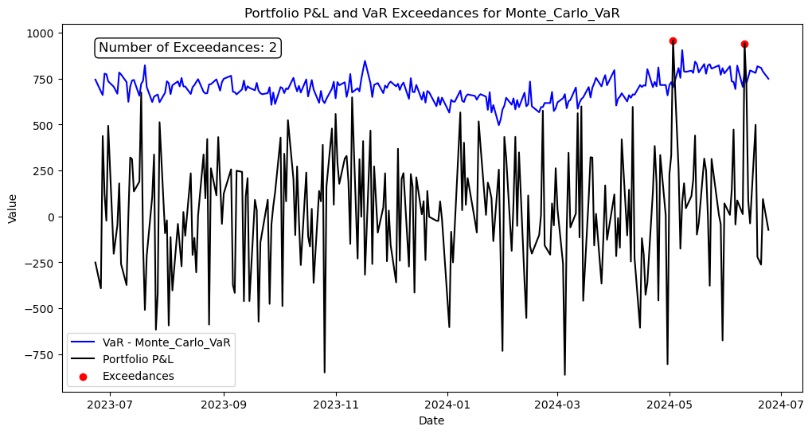

```python
exceedances_sum, last_row_var, mean_last_60_days_var = (
    var_statistics_calculator.calculate_and_plot_exceedances(all_model_VaR)
)
```

### Observations

```python
print("\nExceedances for all models for last 252 days:")
print(exceedances_sum)
```

```
Exceedances for all models for last 252 days:
std                 2
ewma                2
garch_normal        3
garch_ged           3
gjr_garch_normal    3
gjr_garch_ged       3
Historical_VaR      4
Monte_Carlo_VaR     2
dtype: int64
```

```python
print("\nVaR values for the last available date:")
print(last_row_var)
```

```
VaR values for the last available date:
std                  874.233973
ewma                 881.853603
garch_normal        1071.944420
garch_ged           1051.861382
gjr_garch_normal     910.353301
gjr_garch_ged       1060.379452
Historical_VaR       728.095225
Monte_Carlo_VaR      749.653943
Name: 2024-06-24 00:00:00, dtype: float64
```

```python
print("\nMean VaR values over the last 60 days:")
print(mean_last_60_days_var)
```

```
Mean VaR values over the last 60 days:
std                 778.619007
ewma                790.580740
garch_normal        793.004367
garch_ged           801.509300
gjr_garch_normal    784.728128
gjr_garch_ged       797.008971
Historical_VaR      782.792854
Monte_Carlo_VaR     750.265858
dtype: float64
```

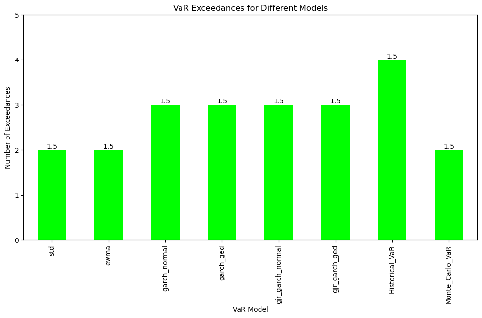

```python
m_values = var_statistics_calculator.plot_exceedances_with_limits()
```

```
Capital required:
                  Capital_Required
std                    1167.928511
ewma                   1185.871109
garch_normal           1189.506551
garch_ged              1202.263951
gjr_garch_normal       1177.092192
gjr_garch_ged          1195.513456
Historical_VaR         1174.189281
Monte_Carlo_VaR        1125.398787
```

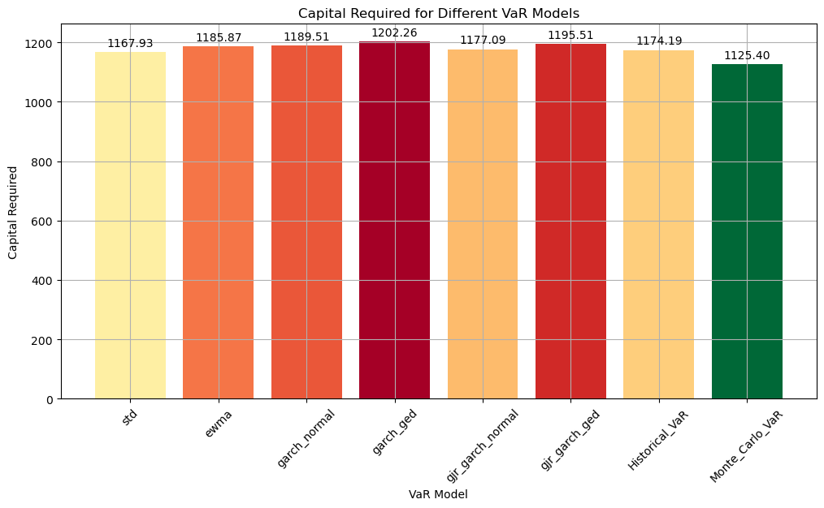

```python
capital_required = var_statistics_calculator.calculate_capital_required()
```

### Recommendation

Given the trade-off between capital requirements and risk accuracy, a combination of models or further analysis may be required to choose the most appropriate VaR model for risk management purposes.

**Note**: GARCH model is taking too much time to run. So, I have commented it out and saved the output in `garch.csv` file. However, it can be uncommented and run again.